# Exam B Solutions

1. Find the derivative of $f(x)=\frac{\sin ^{2} x}{\sqrt{1+x^{2}}}$. Do not simplify your answer.

   **Solution**: Applying the quotient rule, we obtain
   $$\begin{aligned}
   f^{\prime}(x) & =\frac{\sqrt{1+x^{2}} \frac{d}{d x}\left[(\sin x)^{2}\right]-\sin ^{2} x \cdot \frac{d}{d x}\left[\left(1+x^{2}\right)^{1 / 2}\right]}{1+x^{2}} \\
   & =\frac{\sqrt{1+x^{2}} \cdot 2(\sin x)(\cos x)-\sin ^{2} x \cdot \frac{1}{2}\left(1+x^{2}\right)^{-1 / 2}(2 x)}{1+x^{2}}
   \end{aligned}$$
2. If $f(9)=1$, $f^{\prime}(9)=3$, $g(1)=0$, $g^{\prime}(1)=-2$, and $h(x)=x^{3 / 2} e^{g(f(x))}$, then what is $h^{\prime}(9)$? Simplify your answer.

   **Solution**: Applying the product rule, we have
   $$\begin{aligned}
   h^{\prime}(x) & =x^{3 / 2} \frac{d}{d x}\left[e^{g(f(x))}\right]+e^{g(f(x))} \frac{d}{d x}\left[x^{3 / 2}\right] \\
   & =x^{3 / 2} e^{g(f(x))} g^{\prime}(f(x)) f^{\prime}(x)+e^{g(f(x))}(3 / 2) x^{1 / 2}
   \end{aligned}$$
   Thus,
   $$h^{\prime}(9)=9^{3 / 2} e^{g(1)} g^{\prime}(1) f^{\prime}(9)+e^{g(1)}(3 / 2) 9^{1 / 2}=27 e^{0}(-2)(3)+e^{0}(3 / 2)(3)=-\frac{315}{2}$$
3. Below is a portion of the graph of a function $f$.

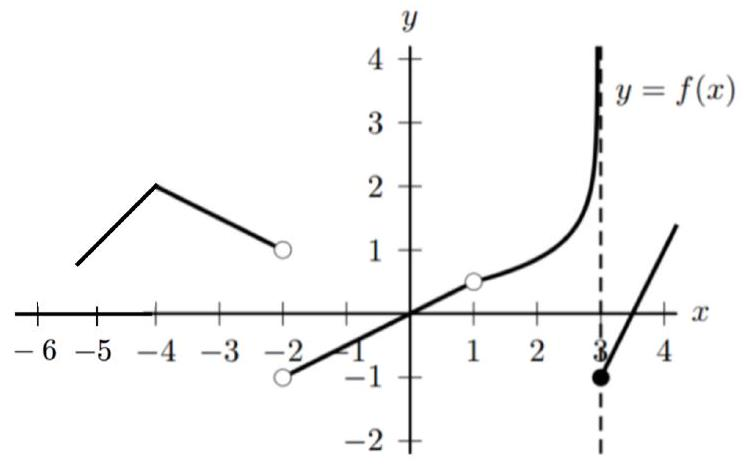

   Original (raster)

[figure not shown]

   Reconstructed (TikZ) — RMSE: 0.1616 FAIL

   For the following, give all values of $a$ in the interval $(-5,4)$ satisfying the given condition. If there are none, write "none". No work is required.
   1. all $a$ not in the domain of $f$: $-2, \quad 1$
   2. all $a$ such that $f$ is not continuous at $a$: $-2, \quad 1, \quad 3$
   3. all $a$ such that $\lim_{x \rightarrow a} f(x)$ does not exist: $-2, \quad 3$
   4. all $a$ at which $f$ is not differentiable: $-4, \quad -2, \quad 1, \quad 3$

   *Grade the problem “correct” even if you made one careless error in filling the blanks.*
4. Find and classify the critical numbers of $f(x)=x^{4 / 5}(x-4)^{2}$, indicating for each critical number whether it yields a relative maximum value of $f$, a relative minimum value, or neither.

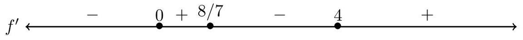

   Original (raster)

[figure not shown]

   Reconstructed (TikZ) — RMSE: 0.2265 FAIL

   Applying the first derivative test (note $f$ is continuous at each of its critical numbers), we see that $f$ has a local minimum at $0$, a local maximum at $8/7$, and a local minimum at $4$.
5. Find the area of the region bounded by the curves $y=x^{2}$ and $y=x+2$.

   **Solution**: The region bounded by the curves $y=x^{2}$ and $y=x+2$ is shaded blue in the figure below.

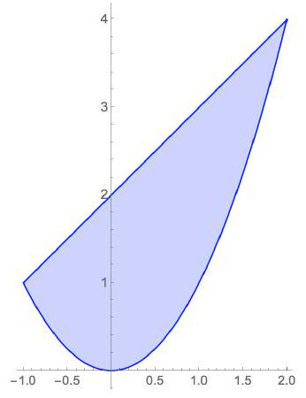

   Original (raster)

[figure not shown]

   Reconstructed (TikZ) — RMSE: 0.1153 PASS

   Its area is given by
   $$\int_{-1}^{2}\left(x+2-x^{2}\right) d x=\left[\frac{x^{2}}{2}+2 x-\frac{x^{3}}{3}\right]_{-1}^{2}=(2+4-8 / 3)-(1 / 2-2+1 / 3)=\frac{9}{2}$$
6. A canister is dropped from a helicopter 500 m above the ground. Its parachute does not open, but the canister has been designed to withstand an impact speed of $120 \mathrm{~m} / \mathrm{s}$. Will it burst? Assume that after it is dropped, the canister experiences (only) the acceleration due to gravity, approximately $10 \mathrm{~m} / \mathrm{s}^{2}$.

   **Solution**: Let $h(t)$ be the height of the canister, in meters, $t$ seconds after it’s dropped (until it hits the ground). We have
   $$h^{\prime \prime}(t)=-10, \quad h(0)=500, \quad \text{and} \quad h^{\prime}(0)=0 \quad \text{(because the canister is dropped).}$$
   Integrating both sides of $h^{\prime \prime}(t)=-10$ yields $h^{\prime}(t)=-10 t+C$, and $h^{\prime}(0)=0$ shows $C=0$. Thus, $h^{\prime}(t)=-10 t$. Integrating both sides of $h^{\prime}(t)=-10 t$ and using $h(0)=500$, we find $h(t)=-5 t^{2}+500$. The canister hits the ground when $h(t)=0$; that is, when $-5 t^{2}+500=0$, so that $t= \pm 10$, but $t=-10$ is irrelevant. Thus, the canister hits the ground after 10 seconds. Its velocity at that instant is $h^{\prime}(10)=-100 \mathrm{~m} / \mathrm{sec}$. Its impact speed is $100 \mathrm{~m} / \mathrm{sec}$; so, we conclude that the canister should not burst.

   *Remark 1*. When grading this problem, consider your solution “correct” provided you found that the canister’s impact speed is $100 \mathrm{~m} / \mathrm{s}$.
7. Find $\int \frac{e^{x}}{1+e^{x}} d x$

   **Solution**:
   $$\begin{aligned}
   \int \frac{e^{x}}{1+e^{x}} d x & =\int \frac{1}{u} d u \quad\left(u=1+e^{x} ; d u=e^{x} d x\right) \\
   & =\ln |u|+C \\
   & =\ln \left|e^{x}+1\right|+C \\
   & =\ln \left(e^{x}+1\right)+C
   \end{aligned}$$
   *Grade the problem “correct” even if you forgot to include $+C$.*
8. Evaluate $\int_{0}^{\pi / 12} \tan ^{3}(3 x) \sec ^{2}(3 x) d x$

   **Solution**:
   $$\begin{aligned}
   \int_{0}^{\pi / 12} \tan ^{3}(3 x) \sec ^{2}(3 x) d x & =\frac{1}{3} \int_{0}^{1} u^{3} d u \quad\left(u=\tan (3 x), d u=3 \sec ^{2}(3 x) d x, \frac{1}{3} d u=\sec ^{2}(3 x) d x\right) \\
   & =\frac{1}{3}\left[\frac{u^{4}}{4}\right]_{0}^{1} \\
   & =\frac{1}{12}
   \end{aligned}$$
9. Over the time interval $1 \leq t \leq 100$ the temperature of a freezer compartment is given by
   $$f(t)=\frac{t-4}{t^{2}}$$
   where $t$ is measured in hours and $f(t)$ is measured in degrees Celsius. What’s the maximum temperature of the freezer over this time interval?

   **Solution**: Because $f$ is continuous on $[1,100]$ (it’s a rational function whose domain includes the entire interval $[1,100]$), the Extreme-Value Theorem tells us that $f$ attains a maximum value at some number, say $c$, in $[1,100]$. This number $c$ must either be an endpoint of $[1,100]$ or a critical number of $f$ in $(1,100)$. We have
   $$f^{\prime}(t)=\frac{t^{2}(1)-(t-4) 2 t}{t^{4}}=\frac{8-t}{t^{3}}$$
   and thus $8$ is the only critical number of $f$ inside $(1,100)$. The largest of the three numbers $f(1), f(8), f(100)$ will be the maximum value of $f$ on $[1,100]$. Since $f(1)=-3, f(8)=1 / 16$, and $f(100)=96 / 10000< 100 / 10000=1 / 100$, we see the maximum temperature of the freezer over the time interval $[1,100]$ is $1/16$ degrees Celsius.
10. Both Rugby Road and Madison Lane meet University Avenue at right angles. (See the diagram below.) Dolly is biking on University Ave at $9 \mathrm{ft} / \mathrm{sec}$ and has passed Madison Ln heading toward Rugby. James is biking away from University Ave along Rugby traveling at $8 \mathrm{ft} / \mathrm{sec}$. At what rate is the distance between Dolly and James changing at the instant when James is 40 ft from and Dolly is 30 ft from the intersection of Rugby Rd and University Ave? Is the distance between them increasing or decreasing at this instant?

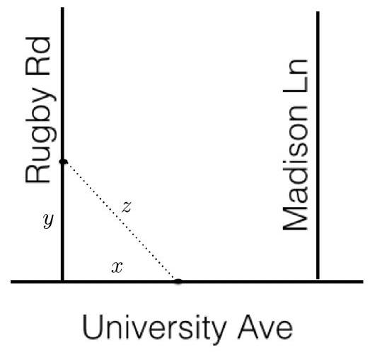

    Original (raster)

[figure not shown]

    Reconstructed (TikZ) — RMSE: 0.2003 FAIL

    As suggested by the diagram above, we let $x$ be the distance, in feet, from Dolly to the intersection of Rugby and University and $y$ be the distance, in feet, from James to the intersection. Finally, we let $z$ be the distance, in feet, from Dolly to James. We are given that
    $$\frac{d x}{d t}=-9 \mathrm{ft} / \mathrm{sec} \quad \text { and } \quad \frac{d y}{d t}=8 \mathrm{ft} / \mathrm{sec} .$$
    We seek $\frac{d z}{d t}$ when $x=30, y=40$, and, by the Pythagorean Theorem, $z=50$.
    The Pythagorean Theorem yields, more generally, that
    $$x^{2}+y^{2}=z^{2}.$$
    Differentiating the preceding equation with respect to time, we obtain
    $$2 x \frac{d x}{d t}+2 y \frac{d y}{d t}=2 z \frac{d z}{d t},$$
    which yields
    $$\frac{d z}{d t}=\frac{1}{z}\left(x \frac{d x}{d t}+y \frac{d y}{d t}\right).$$
    At the time when $x=30$ and $y=40$, we have
    $$\frac{d z}{d t}=\frac{1}{50}(30(-9)+40(8))=1 \mathrm{~ft} / \mathrm{sec}.$$
    Thus when $x=30$ and $y=40$ the distance between Dolly and James is increasing at the rate of 1 ft/sec.